# Data Analytics and Visualizations in R - Exercises

# 2 Advanced R Data Structures and Mathematical Operations

## 2.1 Basic data structures

How would you create a 3 by 4 matrix that contains the numbers 1 to 12 and then convert it into a data frame?

```r
# Answer

x <- matrix(1:12, 3,4)
x <- as.data.frame(x)
x
```

| V1 | V2 | V3 | V4 |
| --- | --- | --- | --- |
| 1 | 4 | 7 | 10 |
| 2 | 5 | 8 | 11 |
| 3 | 6 | 9 | 12 |

## 2.2

Please use the data frame you created in the first question for the next 5 questions. How would you select the second row elements at second and fourth column ?

```r
x <- data.frame(matrix(1:12, 3, 4))
x[2, c(2,4)]
```

|  | X2 | X4 |
| --- | --- | --- |
| 2 | 5 | 11 |

## 2.3

How would you assign zero to the elements at row 2 which are greater than 4?

```r
x <- data.frame(matrix(1:12, 3, 4))
x[2, x[2,]>4] <- 0
x
```

| X1 | X2 | X3 | X4 |
| --- | --- | --- | --- |
| 1 | 4 | 7 | 10 |
| 2 | 0 | 0 | 0 |
| 3 | 6 | 9 | 12 |

## 2.4

How do you set the rownames to “row1”, “row2”, “row3” and column names to “col1”, “col2”, “col3” and “col4” ? (hint:use function “paste0”)

```r
x <- data.frame(matrix(1:12, 3, 4))
rownames(x) <- paste0("row", 1:3)
colnames(x) <- paste0("col", 1:4)
x
```

|  | col1 | col2 | col3 | col4 |
| --- | --- | --- | --- | --- |
| row1 | 1 | 4 | 7 | 10 |
| row2 | 2 | 5 | 8 | 11 |
| row3 | 3 | 6 | 9 | 12 |

## 2.5

How do you assign 0 to all elements in columns “col3” and “col4” by using paste0 function ?

```r
x <- data.frame(matrix(1:12, 3, 4))
colnames(x) <- paste0("col", 1:4)
x[, paste0(0, 3:4)] <- 0
x
```

| col1 | col2 | col3 | col4 | 03 | 04 |
| --- | --- | --- | --- | --- | --- |
| 1 | 4 | 7 | 10 | 0 | 0 |
| 2 | 5 | 8 | 11 | 0 | 0 |
| 3 | 6 | 9 | 12 | 0 | 0 |

## 2.6 `lapply()`

How do you get the numbers whose mod 2 is 0

- by using lapply() function
- by subsetting the data frame directly?

```r
x <- data.frame(matrix(1:12), 3, 4)

lapply(x, function(a) a[(a %% 2) == 0])
```

```
## $matrix.1.12.
## [1]  2  4  6  8 10 12
##
## $X3
## numeric(0)
##
## $X4
##  [1] 4 4 4 4 4 4 4 4 4 4 4 4
```

```r
x[x %% 2 == 0]
```

```
##  [1]  2  4  6  8 10 12  4  4  4  4  4  4  4  4  4  4  4  4
```

## 2.7

Considering `x <- c(“a”=1, “b”=2, “c”=3, “d”=4, “e”=5)`, show how to select the third and fifth elements of x by using positive integers, negative integers, a logical vector, and a character vector.

```r
x <- c("a"=1, "b"=2, "c"=3, "d"=4, "e"=5)
x[c(3,5)]
```

```
## c e
## 3 5
```

```r
x[-c(1,2,4)]
```

```
## c e
## 3 5
```

```r
x[c(F,F,T,F,T)]
```

```
## c e
## 3 5
```

```r
x[c("c", "e")]
```

```
## c e
## 3 5
```

## 2.8

Why are `vals[c(2, 5)]` and `vals[2, 5]` different where `vals <- outer(1:5, 1:5, FUN = “/”)`? How would you select fifth and nineth elements of vals by the use of a matrix?

```r
vals <- outer(1:5, 1:5, FUN = "/")

# Because when you subset matrix with a vector, the 2d matrix behaves
# like a vector and vals[c(2, 5)] returns the elements at indices 2
# and 5 in column-major order. vals[2, 5] returns the element at row 2, column 5.

select <- matrix(ncol=2, byrow=TRUE, c(5,1,4,2))

vals[select]
```

```
## [1] 5 2
```

## 2.9

Consider df <- data.frame(a=paste(“Point_”, 1:20), b=rep(1:4, each = 2, len = 20), c= seq(1,40,length.out = 20), stringsAsFactors = F). Assign “Point_undefined” to column a of all rows of df where column b > 1 and column c > 21 ? What is the reason of the different result that you get if you do the same operation with df being created with option stringsAsFactors = T ?

## 2.10

Assume x <- matrix(1:20, ncol=2). What is the difference between x[1, , drop = T] and x[1, , drop = F]? Now let y <- as.data.frame(x). What is the difference between y[,1] , y[[1]] and y[1]

## 2.11

What is the difference between x[“b”] <- list(NULL) and x[“b”] <- NULL where x <- list(a = c(1:5), b = c(12:15))?

## 2.12

Assume you have a lookup table as lookup <- c(a = “sun”, b = “rain”, c=“wind”, u = NA). How would you generate the weekly weather predictions c(“sun”,“sun”,“rain”, NA, “rain”, “rain”, “wind”) out of this lookup table?

## 2.13

Now assume the weather in winter lookup table is a data frame as below and we have the predictions for the next week as stored in weeklyCast. How would you create “weeklyTable” by the use of rownames function? How would you create it by the use of match function? How would you order the rows of lookup table by desc column?

## 2.14

Consider the bigDF data frame which has 1500 columns and rows. How would you select the even numbered columns named such as “Column_2”, “Column_4”, etc.? How would you select all the columns other than column 76? How would you assign 1 to 500 randomly selected diagonal indices? How can you retrieve the row and column indices of the elements which has been assigned 1? How would you select rows where columns Column_1 or Column_2 are 1 by using the subset() function?

## 2.15

Assume x <- 1:20 %% 2 == 0 and y <- 1:20 %% 5 == 0 . What are the indices of the elements that are True for both x and y? What are the indices of the elements that are True for either x or y, or both?

# 3 Data Import

## 3.1 Flat File - Q1

A csv file has numbers as column names in the first row, i.e. IDs to randomize persons. Which parameter of read.table() needs to be adjusted to read the column names as they are in the csv?

```r
tmp_tidy_table <- "1_colname, 2_colname, 3_colname
3,4,5
a,b,c"
tmp_tidy_table
```

```
## [1] "1_colname, 2_colname, 3_colname\n3,4,5\na,b,c"
```

```r
read.csv(text=tmp_tidy_table)
```

| X1_colname | X2_colname | X3_colname |
| --- | --- | --- |
| 3 | 4 | 5 |
| a | b | c |

```r
# Parameter `check.names`: a logical, tests for synatactically valid varaible
# names

tidy_text_df <- read.csv(text=tmp_tidy_table, check.names = FALSE)
tidy_text_df
```

| 1_colname | 2_colname | 3_colname |
| --- | --- | --- |
| 3 | 4 | 5 |
| a | b | c |

## 3.2 Flat File - Q2

How to read the following table to have the `identical()` information as in `tidy_txt_df` from question above?

```r
tmp_messy_table <- "# This line is just useless info

1_colname,2_colname,3_colname
3,4,5

a,b,c"
```

```r
# To have the identical information as in the previous table we have to check
# which lines are comments. We can do this with `comment.char` parameter.

messy_text_df <- read.csv(text = tmp_messy_table, comment.char = '#', check.names = F)
identical(messy_text_df, tidy_text_df)
```

```
## [1] TRUE
```

## 3.3 Flat File - Q3

Read the `hollywood.tsv` (not *.csv) file into a `data.table` R object. What is the problem with `fread()`?

```r
file_holly_tab <- "extdata/hollywood.tsv"
holly <- as.data.table(read.delim(file_holly_tab), keep_row_names=T)
head(holly)
```

| Film | Genre | Lead.Studio | Audience..score.. | Profitability | Rotten.Tomatoes.. | Worldwide.Gross | Year |
| --- | --- | --- | --- | --- | --- | --- | --- |
| 27 Dresses | Comedy | Fox | 71 | 5.3436218 | 40 | 160.308654 | 2008 |
| (500) Days of Summer | Comedy | Fox | 81 | 8.0960000 | 87 | 60.720000 | 2009 |
| A Dangerous Method | Drama | Independent | 89 | 0.4486447 | 79 | 8.972895 | 2011 |
| A Serious Man | Drama | Universal | 64 | 4.3828571 | 89 | 30.680000 | 2009 |
| Across the Universe | Romance | Independent | 84 | 0.6526032 | 54 | 29.367143 | 2007 |
| Beginners | Comedy | Independent | 80 | 4.4718750 | 84 | 14.310000 | 2011 |

```r
class(holly)
```

```
## [1] "data.table" "data.frame"
```

```r
holly_data_table <- fread(file_holly_tab, skip=1)
class(holly_data_table)
```

```
## [1] "data.table" "data.frame"
```

```r
head(holly_data_table)
```

| V1 | V2 | V3 | V4 | V5 | V6 | V7 | V8 | V9 |
| --- | --- | --- | --- | --- | --- | --- | --- | --- |
| 1 | 27 Dresses | Comedy | Fox | 71 | 5.3436218 | 40 | 160.308654 | 2008 |
| 2 | (500) Days of Summer | Comedy | Fox | 81 | 8.0960000 | 87 | 60.720000 | 2009 |
| 3 | A Dangerous Method | Drama | Independent | 89 | 0.4486447 | 79 | 8.972895 | 2011 |
| 4 | A Serious Man | Drama | Universal | 64 | 4.3828571 | 89 | 30.680000 | 2009 |
| 5 | Across the Universe | Romance | Independent | 84 | 0.6526032 | 54 | 29.367143 | 2007 |
| 6 | Beginners | Comedy | Independent | 80 | 4.4718750 | 84 | 14.310000 | 2011 |

```r
holly_cn <- c("ID", colnames(read.delim(file_holly_tab, nrows= 1)))
holly_cn
```

```
## [1] "ID"                "Film"              "Genre"
## [4] "Lead.Studio"       "Audience..score.." "Profitability"
## [7] "Rotten.Tomatoes.." "Worldwide.Gross"   "Year"
```

```r
# setnames(holly, holly_cn)
# head(holly)
# Difference between them: We can keep row_names. data.frame has no row_names.
```

## 3.4 Flat File - Q4

Who was the oldest surviving passenger of the titanic accident (titanic.csv)? Tipp: `?subset`

```r
tit_df <- read.csv("extdata/titanic.csv")
head(tit_df)
```

|  | pclass | survived | name | sex | age | sibsp | parch | ticket | fare | cabin | embarked | boat | body | home.dest |
| --- | --- | --- | --- | --- | --- | --- | --- | --- | --- | --- | --- | --- | --- | --- |
| 1 | 1 | 1 | Allen, Miss. Elisabeth Walton | female | 29.00 | 0 | 0 | 24160 | 211.3375 | B5 | S | 2 | NA | St Louis, MO |
| 2 | 1 | 1 | Allison, Master. Hudson Trevor | male | 0.92 | 1 | 2 | 113781 | 151.5500 | C22 C26 | S | 11 | NA | Montreal, PQ / Chesterville, ON |
| 3 | 1 | 0 | Allison, Miss. Helen Loraine | female | 2.00 | 1 | 2 | 113781 | 151.5500 | C22 C26 | S |  | NA | Montreal, PQ / Chesterville, ON |
| 4 | 1 | 0 | Allison, Mr. Hudson Joshua Creighton | male | 30.00 | 1 | 2 | 113781 | 151.5500 | C22 C26 | S |  | 135 | Montreal, PQ / Chesterville, ON |
| 5 | 1 | 0 | Allison, Mrs. Hudson J C (Bessie Waldo Daniels) | female | 25.00 | 1 | 2 | 113781 | 151.5500 | C22 C26 | S |  | NA | Montreal, PQ / Chesterville, ON |
| 6 | 1 | 1 | Anderson, Mr. Harry | male | 48.00 | 0 | 0 | 19952 | 26.5500 | E12 | S | 3 | NA | New York, NY |

```r
survivor_name <- subset(tit_df, survived==1 & age==max(age, na.rm = T), name)
survivor_age <- subset(tit_df, survived==1 & age==max(age, na.rm = T), age)

survivor_name
```

|  | name |
| --- | --- |
| 15 | Barkworth, Mr. Algernon Henry Wilson |

```r
survivor_age
```

|  | age |
| --- | --- |
| 15 | 80 |

## 3.5 Excel Questions - Q1

Read only Name, Type and Total columns for only the first 10 pokemons of the pokemon.xlsx file.

## 3.6 Excel Question - Q2

Which athlete won most bronze medals?

## 3.7 Excel Question - Q3

Are the columns Gender and Event_gender consistent?

## 3.8 Excel Question - Q4

Which country won most medals? Which country has the highest ratio of silver medals? Use the data in the country summary sheet starting at row 147.

## 3.9 Excel Questions

Which countries did participate, but without winning medals?

## 3.10 XML - Q1

Load the XML document plant_catalog.xml. Use XPath and DOM functions to find out all unique element names in the document.

Get all plants of zone 4 and transform the data into an R list.

## 3.11 XML - Q2

Read the tables HTML tables from the TUM website of dates for the winter term https://www.tum.de/en/studies/application-and-acceptance/dates-and-deadlines/ dates-and-deadlines-17/ into your workspace. When are the Christmas holidays?

## 3.12 JSON - Q1

Read the countries.json file. Which countries have common border with Jordan? Which country has the most neighbors?

## 3.13 JSON - Q2

Read this JSON file about projects funded by the world bank: world_bank.json.zip. Be aware, you might need to add syntax elements like “[” and “,” to convert the file into textbook JSON format, i.e. readable by R. What was the most expensive project?

## 3.14 SQL - Q1

Use the extdata/Northwind.sl3 SQLite data base and retrieve a table that lists for all customers (name of the company, name of the contact person and city) all the products (name of the product) that they ordered. How many rows does this table have? Display the first 5 rows.

# 4 Grammar of graphics and plotting I

## 4.1 Q1

Match each chart type with the relationship it shows best.

1. shows distribution and quantiles, especially useful when comparing distributions.
2. highlights individual values, supports comparison and can show rankings or deviations categories and totals
3. shows overall changes and patterns, usually over intervals of time
4. shows relationship between two continues variables.

Options: bar chart, line chart, scatterplot, boxplot

```r
# Answer
#
# 1 -> boxplot
# 2 -> bar chart
# 3 -> line chart
# 4. -> scatterplot
```

## 4.2 Q2

`Iris` is a classical dataset in machine learning literature, was first introduced by R.A. Fisher in his 1936 paper. Load the iris data into your R environment. What is the dimension of the dataset and what kind of data type does each column has?

```r
dim(iris)
```

```
## [1] 150   5
```

```r
head(iris)
```

|  | Sepal.Length | Sepal.Width | Petal.Length | Petal.Width | Species |
| --- | --- | --- | --- | --- | --- |
| 1 | 5.1 | 3.5 | 1.4 | 0.2 | setosa |
| 2 | 4.9 | 3.0 | 1.4 | 0.2 | setosa |
| 3 | 4.7 | 3.2 | 1.3 | 0.2 | setosa |
| 4 | 4.6 | 3.1 | 1.5 | 0.2 | setosa |
| 5 | 5.0 | 3.6 | 1.4 | 0.2 | setosa |
| 6 | 5.4 | 3.9 | 1.7 | 0.4 | setosa |

## 4.3 Q3

How are the lengths and widths of sepals and petals distributed? How would you visualize them. Describe what you see. Hint: `facet_wrap(~variable)`.

```r
iris_melt <- melt(iris, id.var=c("Species"))
iris_melt
```

| Species | variable | value |
| --- | --- | --- |
| setosa | Sepal.Length | 5.1 |
| setosa | Sepal.Length | 4.9 |
| setosa | Sepal.Length | 4.7 |
| setosa | Sepal.Length | 4.6 |
| setosa | Sepal.Length | 5.0 |
| setosa | Sepal.Length | 5.4 |
| setosa | Sepal.Length | 4.6 |
| setosa | Sepal.Length | 5.0 |
| setosa | Sepal.Length | 4.4 |
| setosa | Sepal.Length | 4.9 |

[output cut: 590 more lines]

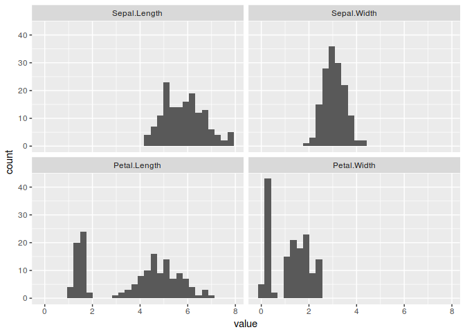

```r
iris_melt %>%
  ggplot(aes(value)) +
  geom_histogram() +
  facet_wrap(~variable)
```